# Session 3

28/10/2021

## Feedback assignment 2

- Deadline is wednesday at noon
- First step is data exploration, which includes removing outliers
- A legend should have an understandable title: “Vegetation types” instead of “Vegtype”
- `ggplot` have themes to change background and overall look
- Saving plots can be done using a function, or using the RStudio interface

## Dates

```r
# Load in the data
library(edcpR)
data(vegdata_a2,  package = "edcpR")
dates <- vegdata_a2$Date
dates
```

```
##   [1] "8.07.2019"  "16.07.2019" "9.07.2019"  "16.07.2019" "1.07.2019"
##   [6] "1.07.2019"  "1.07.2019"  "2.07.2019"  "2.07.2019"  "2.07.2019"
##  [11] "2.07.2019"  "2.07.2019"  "2.07.2019"  "3.07.2019"  "3.07.2019"
##  [16] "3.07.2019"  "3.07.2019"  "3.07.2019"  "4.07.2019"  "4.07.2019"
##  [21] "4.07.2019"  "5.07.2019"  "5.07.2019"  "5.07.2019"  "5.07.2019"
##  [26] "5.07.2019"  "5.07.2019"  "8.07.2019"  "8.07.2019"  "8.07.2019"
##  [31] "8.07.2019"  "8.07.2019"  "9.07.2019"  "9.07.2019"  "9.07.2019"
##  [36] "9.07.2019"  "10.07.2019" "10.07.2019" "10.07.2019" "10.07.2019"
##  [41] "10.07.2019" "11.07.2019" "11.07.2019" "11.07.2019" "11.07.2019"
##  [46] "11.07.2019" "11.07.2019" "15.07.2019" "15.07.2019" "15.07.2019"
##  [51] "15.07.2019" "15.07.2019" "15.07.2019" "16.07.2019" "16.07.2019"
##  [56] "16.07.2019" "16.07.2019" "16.07.2019" "16.07.2019" "17.07.2019"
##  [61] "17.07.2019" "17.07.2019" "17.07.2019" "17.07.2019" "18.07.2019"
##  [66] "18.07.2019" "18.07.2019" "18.07.2019" "18.07.2019" "22/08/2019"
##  [71] "23/08/2019" "22/08/2019" "23/08/2019" "27/08/2019" "27/08/2019"
##  [76] "26/08/2019" "26/08/2019" "26/08/2019" "26/08/2019" "27/08/2019"
##  [81] "28/08/2019" "28/08/2019" "28/08/2019" "28/08/2019" "28/08/2019"
##  [86] "28/08/2019" "28/08/2019" "28/08/2019" "29/08/2019" "29/08/2019"
##  [91] "29/08/2019" "29/08/2019" "28/08/2019" "29/08/2019" "29/08/2019"
##  [96] "30/08/2019" "30/08/2019" "30/08/2019" "30/08/2019" "30/08/2019"
## [101] "43505"      "43505"      "43505"      "43505"      "43505"
## [106] "43533"      "43533"      "43533"      "43533"      "43533"
## [111] "43533"      "43533"      "43533"      "43533"      "43564"
## [116] "43564"      "43564"      "43564"      "43564"      "43564"
## [121] "43564"      "43564"      "43747"      "43747"      "43747"
## [126] "43747"      "43747"      "43747"      "17/09/2019" "17/09/2019"
## [131] "17/09/2019" "17/09/2019" "18/09/2019" "18/09/2019" "18/09/2019"
## [136] "18/09/2019" "19/09/2019" "19/09/2019" "19/09/2019" "19/09/2019"
## [141] "19/09/2019" "19/09/2019" "19/09/2019" "19/08/2019"
```

## Dates

We have the following formats:

- “11/03/2019”
- “11.03.2019”
- “43533”

One is not like the others: Days since “1899-12-30”

A numeric date format is used due to practical reasons: a numeric value takes up less memory then a character string.

## 1899-12-30 ???

Logical would be to choose the origin a “1899-12-31”. This would put “1900-01-01” as day one.

“Lotus 1-2-3”, a predecessor of Excel: 1900 was a leap year

It was not, making all their day counts wrong by one day.

Microsoft noticed it was wrong, but used the format anyway and solved the problem by setting the origin at “1899-12-30”.

## Numeric date formats

```r
# Some numeric dates counting days from an origin
as.numeric(dates) # Only gives dates that can be converted to a number, the rest is NA
```

```
##   [1]    NA    NA    NA    NA    NA    NA    NA    NA    NA    NA    NA    NA
##  [13]    NA    NA    NA    NA    NA    NA    NA    NA    NA    NA    NA    NA
##  [25]    NA    NA    NA    NA    NA    NA    NA    NA    NA    NA    NA    NA
##  [37]    NA    NA    NA    NA    NA    NA    NA    NA    NA    NA    NA    NA
##  [49]    NA    NA    NA    NA    NA    NA    NA    NA    NA    NA    NA    NA
##  [61]    NA    NA    NA    NA    NA    NA    NA    NA    NA    NA    NA    NA
##  [73]    NA    NA    NA    NA    NA    NA    NA    NA    NA    NA    NA    NA
##  [85]    NA    NA    NA    NA    NA    NA    NA    NA    NA    NA    NA    NA
##  [97]    NA    NA    NA    NA 43505 43505 43505 43505 43505 43533 43533 43533
## [109] 43533 43533 43533 43533 43533 43533 43564 43564 43564 43564 43564 43564
## [121] 43564 43564 43747 43747 43747 43747 43747 43747    NA    NA    NA    NA
## [133]    NA    NA    NA    NA    NA    NA    NA    NA    NA    NA    NA    NA
```

## as.Date function

`as.Date()` creates a special data type: Date

It can convert different formats as long as you give it the correct information:

- Character date formats
- Numeric date formats

## Numeric date formats

```r
# Under the hood, R stores the dates as numeric values, but with origin "1970-01-01"
format_1 <- as.Date(as.numeric(dates), origin = "1899-12-30")
format_1[101:128]
```

```
##  [1] "2019-02-09" "2019-02-09" "2019-02-09" "2019-02-09" "2019-02-09"
##  [6] "2019-03-09" "2019-03-09" "2019-03-09" "2019-03-09" "2019-03-09"
## [11] "2019-03-09" "2019-03-09" "2019-03-09" "2019-03-09" "2019-04-09"
## [16] "2019-04-09" "2019-04-09" "2019-04-09" "2019-04-09" "2019-04-09"
## [21] "2019-04-09" "2019-04-09" "2019-10-09" "2019-10-09" "2019-10-09"
## [26] "2019-10-09" "2019-10-09" "2019-10-09"
```

## Character date formats

```r
# Some character dates in two formats
# see for symbols: https://devhints.io/datetime
# Only gives dates that fit format, the rest is set to NA
format_2 <- as.Date(dates, format = "%e.%m.%Y")
format_3 <- as.Date(dates, format = "%e/%m/%Y")

head(format_2)
```

```
## [1] "2019-07-08" "2019-07-16" "2019-07-09" "2019-07-16" "2019-07-01"
## [6] "2019-07-01"
```

## Combining

```r
# Populate a new vector with all non-NA values of the three formats
conv_dates <- format_1
conv_dates[is.na(conv_dates)] <- format_2[is.na(conv_dates)]
conv_dates[is.na(conv_dates)] <- format_3[is.na(conv_dates)]
head(conv_dates) # all in the same format
```

```
## [1] "2019-07-08" "2019-07-16" "2019-07-09" "2019-07-16" "2019-07-01"
## [6] "2019-07-01"
```

## R uses a numeric date format

```r
# Under the hood, R stores the dates as numeric values, but with origin "1970-01-01"
head(conv_dates)
```

```
## [1] "2019-07-08" "2019-07-16" "2019-07-09" "2019-07-16" "2019-07-01"
## [6] "2019-07-01"
```

```r
head(as.numeric(conv_dates))
```

```
## [1] 18085 18093 18086 18093 18078 18078
```

```r
head(as.Date(as.numeric(conv_dates), origin = "1970-01-01"))
```

```
## [1] "2019-07-08" "2019-07-16" "2019-07-09" "2019-07-16" "2019-07-01"
## [6] "2019-07-01"
```

## Session 3: Diversity

## Exercises for today

- Alfa diversity
  - Calculate species richness, shannon and simpson indices
  - Calculate corresponding evenness indices
  - Calculate corresponding Hill numbers
  - Plot relationships between different alfa diversity measures
- Beta diversity
  - Calculate pairwise beta diversity
  - Partition beta diversity in nestedness and turnover components
  - Calculate multiple site beta diversity
- Gamma diversity
- Functional diversity

## Data for today

We will use data that is provided by the `vegan` package.

```r
library(vegan)
data("BCI", package = "vegan")
```

## Exercises: part 1 (20 min)

- Alfa diversity
  - Calculate species richness, shannon and simpson indices
    - **TIP**: `vegan` package
  - Calculate corresponding evenness indices
    - **TIP**: use formulas provided in the lecture slides
  - Calculate corresponding Hill numbers
    - **TIP**: `tsallis()` function
  - Plot relationships between different alfa diversity measures

## Load in data

```r
# Load in the packages which we will use
library(vegan)
```

```r
# Load data
data("BCI")
head(BCI[, c(1,2,5)])
```

```
##   Abarema.macradenia Vachellia.melanoceras Adelia.triloba
## 1                  0                     0              0
## 2                  0                     0              0
## 3                  0                     0              0
## 4                  0                     0              3
## 5                  0                     0              1
## 6                  0                     0              0
```

## Calculate species richness (1)

```r
# Species richness
S <- specnumber(BCI)
head(S)
```

```
##   1   2   3   4   5   6
##  93  84  90  94 101  85
```

## Calculate shannon index (2)

```r
# Shannon index
H <- diversity(BCI, "shannon")
head(H)
```

```
##        1        2        3        4        5        6
## 4.018412 3.848471 3.814060 3.976563 3.969940 3.776575
```

## Calculate simpson index (3)

```r
# This function returns 1-D!
D <- diversity(BCI, "simpson")
head(D)
```

```
##         1         2         3         4         5         6
## 0.9746293 0.9683393 0.9646078 0.9716117 0.9678267 0.9627557
```

## Calculate simpson index (4)

```r
# This function returns 1/D
invD <- diversity(BCI, "inv")
head(invD)
```

```
##        1        2        3        4        5        6
## 39.41555 31.58488 28.25478 35.22577 31.08166 26.84973
```

## Calculate corresponding evenness indices (1)

```r
#Shannon evenness
J <- H/(log(S))
head(J)
```

```
##         1         2         3         4         5         6
## 0.8865579 0.8685692 0.8476046 0.8752597 0.8602030 0.8500724
```

## Calculate corresponding evenness indices (2)

```r
#Simpson evenness
E <- invD/S
head(E)
```

```
##         1         2         3         4         5         6
## 0.4238232 0.3760104 0.3139420 0.3747422 0.3077392 0.3158792
```

## Calculate corresponding Hill numbers (1)

```r
Hill <- tsallis(BCI, hill=TRUE, scales=c(0,1,2))
head(Hill)
```

```
##     0        1        2
## 1  93 55.61270 39.41555
## 2  84 46.92127 31.58488
## 3  90 45.33410 28.25478
## 4  94 53.33341 35.22577
## 5 101 52.98137 31.08166
## 6  85 43.66624 26.84973
```

## Calculate corresponding Hill numbers (2)

```r
#This should equal (see lecture formulas)
sum(Hill[, 1]) == sum(S)
```

```
## [1] TRUE
```

```r
sum(Hill[, 2]) == sum(exp(H))
```

```
## [1] TRUE
```

```r
sum(Hill[, 3]) == sum(invD)
```

```
## [1] FALSE
```

## Calculate corresponding Hill numbers (3)

```r
#Simpson diversity gives FALSE when it should be TRUE?
sum(Hill[, 3])
```

```
## [1] 1389.517
```

```r
sum(invD)
```

```
## [1] 1389.517
```

## Plot relationships (1)

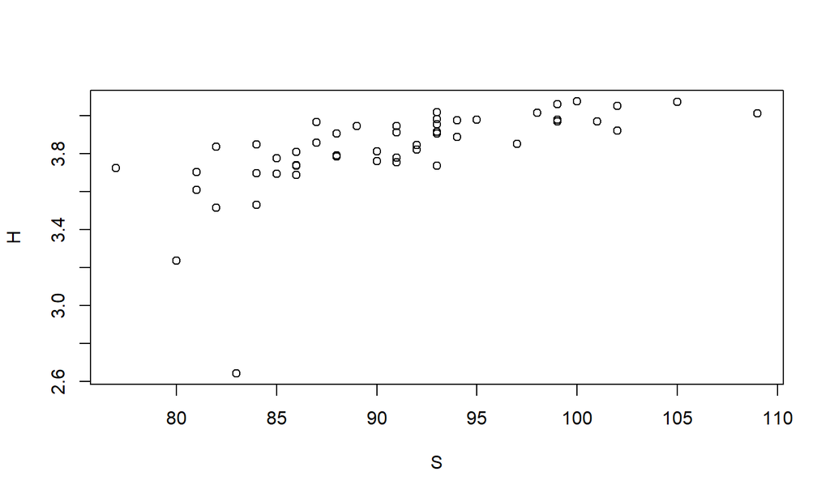

```r
plot(S,H)
```

## Plot relationships (2)

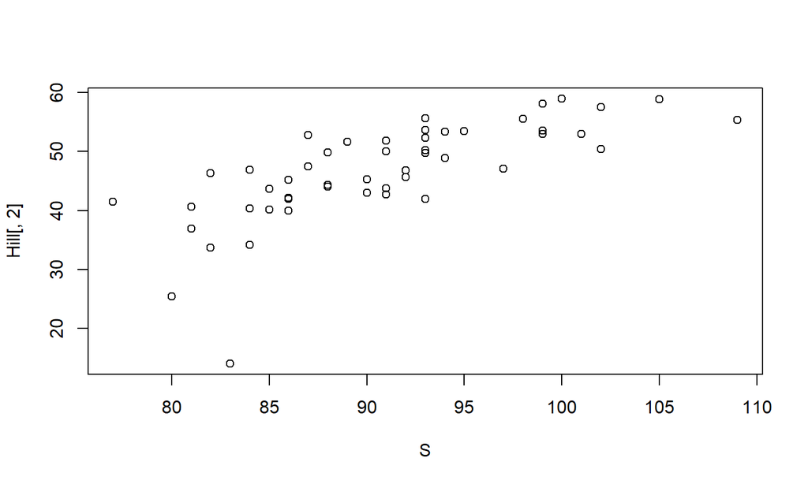

```r
plot(S,Hill[,2])
```

## Exercises: part 2 (25 min)

- Beta diversity
  - Calculate pairwise beta diversity
    - **TIP**: `betadiver()`
  - Partition beta diversity in nestedness and turnover components
    - **TIP**: `betapart` package
    - **TIP**: tranform to presence/abscence data!
  - Calculate multiple site beta diversity

## Calculate pairwise beta diversity (1)

```r
#It is very important to first check which formula you will use
betadiver(help = TRUE)
```

```
## 1 "w" = (b+c)/(2*a+b+c)
## 2 "-1" = (b+c)/(2*a+b+c)
## 3 "c" = (b+c)/2
## 4 "wb" = b+c
## 5 "r" = 2*b*c/((a+b+c)^2-2*b*c)
## 6 "I" = log(2*a+b+c) - 2*a*log(2)/(2*a+b+c) - ((a+b)*log(a+b) +
## (a+c)*log(a+c)) / (2*a+b+c)
## 7 "e" = exp(log(2*a+b+c) - 2*a*log(2)/(2*a+b+c) - ((a+b)*log(a+b) +
## (a+c)*log(a+c)) / (2*a+b+c))-1
## 8 "t" = (b+c)/(2*a+b+c)
## 9 "me" = (b+c)/(2*a+b+c)
## 10 "j" = a/(a+b+c)
## 11 "sor" = 2*a/(2*a+b+c)
## 12 "m" = (2*a+b+c)*(b+c)/(a+b+c)
## 13 "-2" = pmin(b,c)/(pmax(b,c)+a)
## 14 "co" = (a*c+a*b+2*b*c)/(2*(a+b)*(a+c))
## 15 "cc" = (b+c)/(a+b+c)
## 16 "g" = (b+c)/(a+b+c)
## 17 "-3" = pmin(b,c)/(a+b+c)
## 18 "l" = (b+c)/2
## 19 "19" = 2*(b*c+1)/(a+b+c)/(a+b+c-1)
## 20 "hk" = (b+c)/(2*a+b+c)
## 21 "rlb" = a/(a+c)
## 22 "sim" = pmin(b,c)/(pmin(b,c)+a)
## 23 "gl" = 2*abs(b-c)/(2*a+b+c)
## 24 "z" = (log(2)-log(2*a+b+c)+log(a+b+c))/log(2)
```

## Calculate pairwise beta diversity (2)

```r
#Depending on the formula, you will get a (dis)similarity matrix!
#Notice that there also is a "sor" option (= different from the one in lectures)
sorensen <- betadiver(BCI[1:5, ], "w")
sorensen
```

```
##           1         2         3         4
## 2 0.2768362
## 3 0.3005464 0.2873563
## 4 0.2834225 0.2808989 0.2717391
## 5 0.2989691 0.3081081 0.2984293 0.2615385
```

## Calculate pairwise beta diversity (3)

```r
#Transform into a data frame to get a nice overview between plots
dissimilarity <- scores(sorensen)
dissimilarity
```

```
##           1         2         3         4         5
## 1 0.0000000 0.2768362 0.3005464 0.2834225 0.2989691
## 2 0.2768362 0.0000000 0.2873563 0.2808989 0.3081081
## 3 0.3005464 0.2873563 0.0000000 0.2717391 0.2984293
## 4 0.2834225 0.2808989 0.2717391 0.0000000 0.2615385
## 5 0.2989691 0.3081081 0.2984293 0.2615385 0.0000000
```

## Nestedness and turnover components (1)

```r
#Beta diversity can be partitioned in nestedness & turnover
#Both components can be calculated with the betapart package
library(betapart)
```

## Nestedness and turnover components (2)

```r
#Partitioning only works for presence/absence data
#Transform all values larger than 0 to 1
PA <- BCI
PA[PA > 0] <- 1
```

## Nestedness and turnover components (3)

```r
#First matrix is turnover (SIM)
components <- beta.pair(PA[1:5, ], index.family = "sorensen")
components$beta.sim
```

```
##           1         2         3         4
## 2 0.2380952
## 3 0.2888889 0.2619048
## 4 0.2795699 0.2380952 0.2555556
## 5 0.2688172 0.2380952 0.2555556 0.2340426
```

## Nestedness and turnover components (4)

```r
#Second matrix is nestedness (SNE)
components$beta.sne
```

```
##             1           2           3           4
## 2 0.038740920
## 3 0.011657559 0.025451560
## 4 0.003852567 0.042803638 0.016183575
## 5 0.030151868 0.070012870 0.042873764 0.027495908
```

```r
#Third matrix is the sum & should equal the previous calculation of sorensen beta diversity
components$beta.sor
```

```
##           1         2         3         4
## 2 0.2768362
## 3 0.3005464 0.2873563
## 4 0.2834225 0.2808989 0.2717391
## 5 0.2989691 0.3081081 0.2984293 0.2615385
```

## Calculate multiple site beta diversity (1)

```r
#Multiple site beta diversity (= one value for all sites)
#This corresponds to the differences between all sites
#Again, this is immediately partitioned in the two part (Turnover & Nestedness)
beta.multi(PA, index.family="sorensen")
```

```
## $beta.SIM
## [1] 0.8840073
##
## $beta.SNE
## [1] 0.01347489
##
## $beta.SOR
## [1] 0.8974822
```

## Exercises: part 3 (25 min)

- Gamma diversity
  - Calculate chao estimators for the BCI dataset
    - **TIP**: `specpool()`
  - An old dataset has the following Chao estimators: Chao = 280 (SE = 11.5)
    - Did we lose or gain species?

## Calculate gamma diversity

```r
#Calculate plot-based gamma diversity with chao estimators
BCI_gamma <- specpool(BCI)
BCI_gamma
```

```
##     Species     chao chao.se  jack1 jack1.se    jack2     boot  boot.se  n
## All     225 236.3732 6.54361 245.58 5.650522 247.8722 235.6862 3.468888 50
```

## Calculate gamma diversity

```r
#Extract the mean and standard error
chao_BCI <- BCI_gamma$chao
chao_BCI_se <- BCI_gamma$chao.se
chao_BCI
```

```
## [1] 236.3732
```

```r
chao_BCI_se
```

```
## [1] 6.54361
```

## Calculate gamma diversity

```r
#Take 100 random samples from a normal distribution!
sample_BCI <- rnorm(100, mean = chao_BCI, sd = chao_BCI_se)
head(sample_BCI)
```

```
## [1] 230.9831 246.5028 223.9506 237.9055 235.8031 236.4025
```

```r
sample <- rnorm(100, mean = 280, sd = 11.5)
head(sample)
```

```
## [1] 277.6814 295.4982 294.1960 284.5443 279.3703 266.1101
```

## Calculate gamma diversity

```r
#Perform a t-test
t.test(sample_BCI, sample)
```

```
##
##  Welch Two Sample t-test
##
## data:  sample_BCI and sample
## t = -34.149, df = 151.37, p-value < 2.2e-16
## alternative hypothesis: true difference in means is not equal to 0
## 95 percent confidence interval:
##  -46.38203 -41.30856
## sample estimates:
## mean of x mean of y
##  236.6116  280.4569
```

```r
#p-value < 0.05 --> reject the zero-hypothesis --> significant difference!
#We lost species!
```

## Exercises: part 4 (25 min)

- Functional diversity
  - Calculate the functional diversity indices from the Tussock dataset:
    - **TIP**: `tussock` dataset from `FD` package
    - **TIP**: `dbFD()`

## Calculate functional diversity (1)

```r
#load library
library(FD)
```

## Calculate functional diversity (2)

```r
#We will make use of the Tussock dataset (= part of the package FD)
#First we need to split abundance data from trait data
traits <- tussock$trait
abundance <- tussock$abun
```

## Calculate functional diversity (3)

```r
#Now we need to clean the trait data
#We will only use continuous traits and not seedmass because we are interested in the plant itself
#We also need to remove species on which we have no trait data
traits <- traits[, c(2:7, 11)]
traits <- na.omit(traits)
head(traits)
```

```
##            height     LDMC leafN leafP leafS       SLA  leafsize
## Achi_mill 0.09727 163.1264   3.4 0.310 0.210 15.637656 313.51484
## Agro_capi 0.19100 302.7657   2.5 0.250 0.180 21.846627 141.78019
## Anth_odor 0.06350 280.2013   2.0 0.240 0.150 24.547661 161.43904
## Apha_arve 0.04470 185.9606   1.7 0.290 0.180 18.587383  20.89516
## Arre_elat 0.56400 311.9551   2.6 0.256 0.174 20.777386 805.42883
## Brac_bell 0.00338 223.5052   1.2 0.330 0.220  6.549107 216.33835
```

## Calculate functional diversity (4)

```r
#Only select the species that do have traits!
#We omitted two, so here those two should also be deleted
abundance <- abundance[, rownames(traits)]
```

## Calculate functional diversity (5)

```r
#Calculate species richness
#Transform abundance to a data frame
spec_richness <- rowSums(abundance != 0)
abundance <- as.data.frame(abundance)
```

## Calculate functional diversity (6)

```r
# Calculate all FD indices
FD <- dbFD(traits, abundance)
```

```
## FRic: No dimensionality reduction was required. All 7 PCoA axes were kept as 'traits'.
```

```r
# You wil see FD is a list containing different functional diversity indices
# Functional richness, functional eveness, functional divergence...
```

## Calculate functional diversity (7)

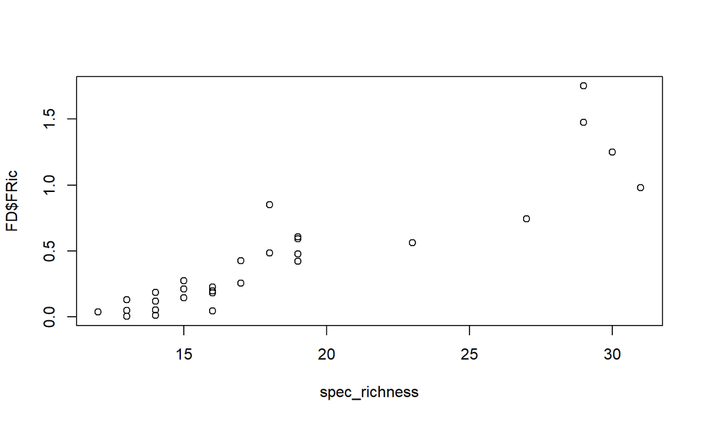

```r
# Plot FD vs species diversity
plot(spec_richness, FD$FRic)
```

## Conclusion?

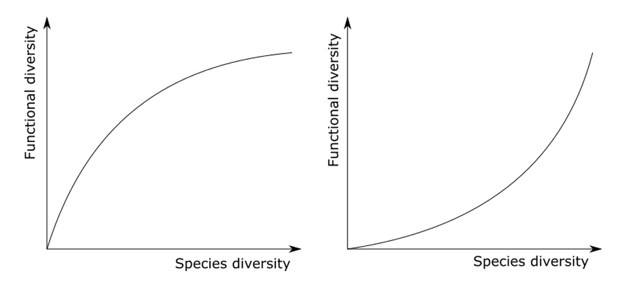

## Assignment 3

Access the assignment:

```r
vignette("assignment-3", package = "edcpR")
```

Remember to upload everything before **November 3rd, 12 am (= at noon!)**.